```python
import sys
# For notebooks inside research/ftir_hips_chem/:
sys.path.insert(0, './scripts')
sys.path.insert(0, './workflows')

import pandas as pd
import numpy as np
import matplotlib.pyplot as plt
from pathlib import Path
from IPython.display import display, Markdown

# Canonical research configuration, loaders, exclusions and plotting style.
from config import (SITES, PROCESSED_SITES_DIR, FILTER_DATA_PATH,
                    AERONET_DATA_DIR, WEATHER_DATA_DIR, MAC_VALUE)
from outliers import (EXCLUDED_SAMPLES, MANUAL_OUTLIERS, apply_exclusion_flags,
                      apply_threshold_flags, get_clean_data, print_exclusion_summary)
from data_matching import (load_aethalometer_data, load_filter_data,
                           match_aeth_filter_data, match_all_parameters)
from etad_factors import load_etad_factor_contributions, match_etad_factors
from aeronet import load_aeronet, aeronet_dir, COLS as AERONET_COLS
from improve_io import load_improve_clean
from plotting import PlotConfig, crossplots, timeseries, distributions, comparisons
from plotting.utils import calculate_regression_stats

from vibes_followup_studies import (SOURCE, OUTPUT, load_inputs, common_test,
                                    routing_study, addis_gate, write_manifest)

PlotConfig.set(sites='all', layout='individual', show_stats=True, show_1to1=True)
FIGURES = Path('output/plots/vibes_followup_notebook')
FIGURES.mkdir(parents=True, exist_ok=True)
```

# AIRSpec / VIBES: common-test selection and spectrum-only routing

## tl;dr

On the same **2,327 IMPROVE test filters**, the full-pool AIRSpec model has RMSE **3.224 µg/filter**. The best of the four 500-filter analog models has RMSE **4.837** (VIBES with the 1800–2500 and >3500 selection cuts); the historical lowest-OC/EC models have **16.759** (AIRSpec) and **13.098** (VIBES) when extended to the full test population. The spectrum-only router has RMSE **6.095** versus AIRSpec **6.093** in nested training-site folds, and **3.168** versus **3.224** on the previously examined outer sites; its paired outer-site interval includes zero. These are exploratory comparisons, not a fresh confirmatory validation. The Addis reference gate finds **no independent thermal EC matches**, so it reports no Addis accuracy metric. No original correction or exclusion flag is changed.

## Context & Methods

- Source: completed 2026-09-21 full Colab run, `output/tables/vibes_colab_cloud/ persistent_results/full-83dcf32e86bc0f09/`.
- Population: 10,066 eligible training and 2,327 disjoint-site test IMPROVE physical filters, plus 253 unlabeled Addis target spectra. TOR EC is in **µg/filter**. Saved methods share the original 2,002-channel grid.
- Lowest-OC/EC membership is fixed historical selection using carbon labels; it is not a prediction-time classifier.
- Analog membership is selected from **training sites only** by mean Pearson similarity to Addis target spectra corrected by AIRSpec. All variants choose 500 physical filters. Each mask changes similarity ranking only; every PLS model still uses all 2,002 channels. The full-pool component counts (AIRSpec 6, VIBES 7) are fixed for analog fits. No outer-test EC is used in selection.
- The router uses 16 spectrum-only regional mean/SD features from the two corrected spectra. Its labels come from grouped out-of-fold training-site predictions. An outer grouped loop evaluates the training procedure; the final router is then fit using all training sites and scored on the previously examined original test sites. No test site, TOR loading, HIPS or location enters the routing features. No router threshold or feature set is optimized here. The nested folds share the already fitted blank-based correction; only the **EC calibration and router** are refit per fold, so this is conditional on saved preprocessing, not an end-to-end independent baseline test.
- Paired 95% intervals resample entire test sites (2,000 draws) and are conditional on fitted models; they do not cover model development or the many exploratory contrasts.

### Key Assumptions

The completed run's case ledger, paired corrected arrays, and split remain unaltered. This notebook refits PLS from those **saved corrected arrays**; it does not rerun AIRSpec or VIBES baseline correction. The fixed Addis spectra are used only as unlabeled selection targets. Repeated exploration of the old test set limits inference about any apparent improvement.

## Data · freeze and reconcile the completed run

```python
inputs = load_inputs()
write_manifest(inputs)
print('Source signature:', inputs['manifest']['signature'])
print('Cases:', len(inputs['cases']), '| train:', len(inputs['train']),
      '| common test:', len(inputs['test']), '| Addis targets:', len(inputs['targets']))
print('Train/test sites:', inputs['cases'].Site.iloc[inputs['train']].nunique(),
      inputs['cases'].Site.iloc[inputs['test']].nunique())
print('Input hashes written to', OUTPUT / 'input_manifest.json')
```

```
Source signature: 83dcf32e86bc0f092f49f7f59671ac8a89f8efcc28d990287f8b1f895d2b2ae5
Cases: 12808 | train: 10066 | common test: 2327 | Addis targets: 253
Train/test sites: 125 32
Input hashes written to research/ftir_hips_chem/output/tables/vibes_followup_notebook/input_manifest.json
```

## Results · common-test calibration selections

The original restricted cohort was previously evaluated on only 137 of these test filters. Here it is refit with its original 625 training members and scored on **all 2,327** test filters, exactly like the full-pool and new analog fits. Original saved predictions must reproduce on their original shared rows. This is a new site-restricted AIRSpec-based analog selection, not the exact September 10 selection population, so membership-change counts will differ.

```python
selection_metrics, selection_predictions, selected_filters = common_test(inputs)
display(selection_metrics[['model','method','n_train','n_train_sites','components',
                           'n','RMSE','MAE','bias','predictive_R2',
                           'delta_RMSE_vs_full_AIRSpec','delta_RMSE_CI_low',
                           'delta_RMSE_CI_high']].round(3))
overlap = pd.read_json(OUTPUT / 'selection_overlap.json').T
display(overlap)
display(pd.read_csv(OUTPUT / 'restricted_membership_sensitivity.csv').round(3))
```

|  | model | method | n_train | n_train_sites | components | n | RMSE | MAE | bias | predictive_R2 | delta_RMSE_vs_full_AIRSpec | delta_RMSE_CI_low | delta_RMSE_CI_high |
| --- | --- | --- | --- | --- | --- | --- | --- | --- | --- | --- | --- | --- | --- |
| 0 | full_pool | AIRSpec | 10066 | 125 | 6 | 2327 | 3.224 | 1.891 | 0.294 | 0.679 | 0.000 | 0.000 | 0.000 |
| 1 | full_pool | VIBES | 10066 | 125 | 7 | 2327 | 3.296 | 1.952 | 0.294 | 0.664 | 0.071 | -0.084 | 0.257 |
| 2 | locked800 | AIRSpec | 625 | 101 | 5 | 2327 | 16.759 | 9.596 | 9.446 | -7.685 | 13.535 | 10.818 | 16.228 |
| 3 | locked800 | VIBES | 625 | 101 | 7 | 2327 | 13.098 | 7.145 | 6.868 | -4.305 | 9.874 | 8.056 | 11.559 |
| 4 | analog_full | AIRSpec | 500 | 93 | 6 | 2327 | 5.424 | 3.010 | -1.245 | 0.090 | 2.200 | 1.602 | 2.786 |
| 5 | analog_full | VIBES | 500 | 93 | 7 | 2327 | 4.951 | 2.853 | 1.944 | 0.242 | 1.726 | 1.066 | 2.364 |
| 6 | analog_exclude_1800_2500 | AIRSpec | 500 | 93 | 6 | 2327 | 5.450 | 3.126 | -1.417 | 0.081 | 2.226 | 1.621 | 2.841 |
| 7 | analog_exclude_1800_2500 | VIBES | 500 | 93 | 7 | 2327 | 4.879 | 2.787 | 1.791 | 0.264 | 1.655 | 1.026 | 2.269 |
| 8 | analog_exclude_1800_2500_above_3600 | AIRSpec | 500 | 95 | 6 | 2327 | 5.196 | 3.052 | -1.313 | 0.165 | 1.971 | 1.390 | 2.594 |
| 9 | analog_exclude_1800_2500_above_3600 | VIBES | 500 | 95 | 7 | 2327 | 5.126 | 2.930 | 2.058 | 0.187 | 1.902 | 1.266 | 2.511 |
| 10 | analog_exclude_1800_2500_above_3500 | AIRSpec | 500 | 90 | 6 | 2327 | 5.949 | 3.469 | -1.652 | -0.094 | 2.725 | 1.883 | 3.590 |
| 11 | analog_exclude_1800_2500_above_3500 | VIBES | 500 | 90 | 7 | 2327 | 4.837 | 2.918 | 2.049 | 0.277 | 1.612 | 1.150 | 2.067 |

|  | replaced_vs_unmasked | n_training_sites |
| --- | --- | --- |
| analog_full | 0 | 93 |
| analog_exclude_1800_2500 | 15 | 93 |
| analog_exclude_1800_2500_above_3600 | 44 | 95 |
| analog_exclude_1800_2500_above_3500 | 63 | 90 |

|  | method | in_historical_membership | n | RMSE | MAE | bias | predictive_R2 |
| --- | --- | --- | --- | --- | --- | --- | --- |
| 0 | AIRSpec | False | 2190 | 17.263 | 10.097 | 10.018 | -8.533 |
| 1 | AIRSpec | True | 137 | 2.548 | 1.581 | 0.294 | 0.868 |
| 2 | VIBES | False | 2190 | 13.488 | 7.478 | 7.300 | -4.820 |
| 3 | VIBES | True | 137 | 2.420 | 1.824 | -0.040 | 0.881 |

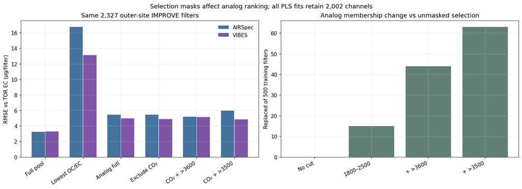

```python
models = list(selection_metrics.model.drop_duplicates())
fig, axes = plt.subplots(1, 2, figsize=(14, 5), constrained_layout=True)
x = np.arange(len(models))
for offset, method in [(-.18, 'AIRSpec'), (.18, 'VIBES')]:
    part = selection_metrics.set_index(['model','method']).loc[[(m,method) for m in models]]
    axes[0].bar(x+offset, part.RMSE, width=.35,
                color='#44749d' if method=='AIRSpec' else '#7e54a8', label=method)
axes[0].set_xticks(x, ['Full pool','Lowest OC/EC','Analog full','Exclude CO₂',
                        'CO₂ + >3600','CO₂ + >3500'], rotation=35, ha='right')
axes[0].set_ylabel('RMSE vs TOR EC (µg/filter)')
axes[0].set_title('Same 2,327 outer-site IMPROVE filters')
axes[0].legend(frameon=False)
analog = overlap.loc[[m for m in models if m.startswith('analog_')]]
axes[1].bar(np.arange(len(analog)), analog.replaced_vs_unmasked,
            color='#617f76')
axes[1].set_xticks(np.arange(len(analog)), ['No cut','1800–2500',
                                            '+ >3600','+ >3500'], rotation=25, ha='right')
axes[1].set_ylabel('Replaced of 500 training filters')
axes[1].set_title('Analog membership change vs unmasked selection')
fig.suptitle('Selection masks affect analog ranking; all PLS fits retain 2,002 channels')
fig.savefig(FIGURES / 'common_test_selection.png', bbox_inches='tight')
plt.show()
```

The restricted model's earlier 137-filter result does not generalize to all outer-site filters: it has far larger error on the 2,190 filters outside historical membership. That is a population shift result, not proof of a particular chemical mechanism. The analog-model contrasts are also retrospective; inspect paired site intervals and membership before interpreting small differences. A masked analog model is distinct from deleting spectral channels in PLS.

## Results · spectrum-only routing

The nested training-site rows estimate how the **router-training procedure** behaves when entire training sites are left out. The final row uses the original outer sites, which have been inspected in earlier work. We report both because the second alone could reward decisions suggested by previous test charts.

```python
routing_metrics, routing_predictions = routing_study(inputs)
display(routing_metrics[['population','method','n','n_sites','selected_VIBES',
                         'RMSE','MAE','bias','predictive_R2',
                         'delta_RMSE_vs_AIRSpec','delta_RMSE_CI_low',
                         'delta_RMSE_CI_high']].round(3))
display(pd.read_csv(OUTPUT / 'routing_largest_VIBES_errors.csv').head(3))
```

|  | population | method | n | n_sites | selected_VIBES | RMSE | MAE | bias | predictive_R2 | delta_RMSE_vs_AIRSpec | delta_RMSE_CI_low | delta_RMSE_CI_high |
| --- | --- | --- | --- | --- | --- | --- | --- | --- | --- | --- | --- | --- |
| 0 | training_site_nested | AIRSpec | 10066 | 125 | NaN | 6.093 | 2.334 | 0.004 | 0.637 | 0.000 | 0.000 | 0.000 |
| 1 | training_site_nested | VIBES | 10066 | 125 | NaN | 13.082 | 2.453 | -0.081 | -0.676 | 6.989 | -0.232 | 15.370 |
| 2 | training_site_nested | routed | 10066 | 125 | 4902.0 | 6.095 | 2.237 | -0.086 | 0.636 | 0.002 | -0.522 | 0.666 |
| 3 | prior_inspected_test | AIRSpec | 2327 | 32 | NaN | 3.224 | 1.891 | 0.294 | 0.679 | 0.000 | 0.000 | 0.000 |
| 4 | prior_inspected_test | VIBES | 2327 | 32 | NaN | 3.296 | 1.952 | 0.294 | 0.664 | 0.071 | -0.084 | 0.257 |
| 5 | prior_inspected_test | routed | 2327 | 32 | 1208.0 | 3.168 | 1.867 | 0.173 | 0.690 | -0.056 | -0.188 | 0.090 |

|  | sample_id | Site | y | fold | choice | AIRSpec | VIBES | routed | VIBES_abs_error |
| --- | --- | --- | --- | --- | --- | --- | --- | --- | --- |
| 0 | improve:2008808 | TONT1 | 5.609067 | 4 | AIRSpec | 4.421990 | -1147.648247 | 4.421990 | 1153.257315 |
| 1 | improve:1967866 | TOOL1 | 393.327086 | 3 | VIBES | 199.969785 | 175.088638 | 175.088638 | 218.238449 |
| 2 | improve:1851843 | PHOE1 | 89.424038 | 2 | VIBES | 184.679505 | 301.670268 | 301.670268 | 212.246230 |

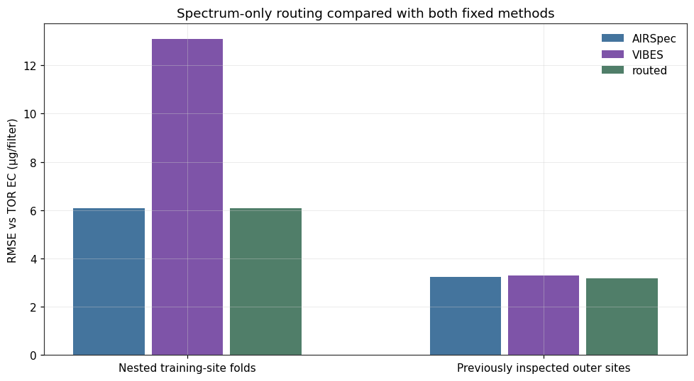

```python
fig, ax = plt.subplots(figsize=(9, 5))
populations = ['training_site_nested','prior_inspected_test']
labels = ['Nested training-site folds','Previously inspected outer sites']
for i, population in enumerate(populations):
    part = routing_metrics.set_index(['population','method'])
    for j, method in enumerate(['AIRSpec','VIBES','routed']):
        value = part.loc[(population,method),'RMSE']
        ax.bar(i + (j-1)*.22, value, width=.2,
               color={'AIRSpec':'#44749d','VIBES':'#7e54a8','routed':'#507e69'}[method],
               label=method if i==0 else None)
ax.set_xticks(range(2), labels)
ax.set_ylabel('RMSE vs TOR EC (µg/filter)')
ax.set_title('Spectrum-only routing compared with both fixed methods')
ax.legend(frameon=False)
fig.tight_layout()
fig.savefig(FIGURES / 'routing_comparison.png', bbox_inches='tight')
plt.show()
```

The nested VIBES RMSE is dominated by a severe TONT1 prediction (`improve:2008808`, about −1148 versus TOR 5.61 µg/filter). It remains in all scores; the router selected AIRSpec for that filter. On the previously examined outer sites the router's RMSE difference from AIRSpec is −0.056 µg/filter, with a paired site-bootstrap interval of −0.188 to 0.090. This does not establish a benefit, and the old test has already been studied.

## Results · independent Addis reference gate

This is a **readiness check**, not an accuracy estimate. The 253 Addis targets have frozen predictions but no independently measured, identity-confirmed TOR EC in the completed run. A future reference file may be passed as `AETH_ADDIS_VALIDATION_CSV`; it must contain unique `sample_id`, distinct `ptfe_filter_id` and `quartz_filter_id`, `TOR_EC_loading_ug`, `reference_method`, `reference_source`, `authoritative_match`, and `sampling_equivalent`. The gate rejects unconfirmed identity or sampling equivalence. It does not automatically score newly unblinded values; the already frozen validation protocol governs that separate analysis.

```python
addis_status = addis_gate(inputs)
display(addis_status)
```

```
{'status': 'reference_unavailable',
 'n_addis_targets': 253,
 'n_independent_thermal_matches': 0,
 'addis_prediction_sha256': 'c2cd8f34ee0b4f0fc37b345a4f1afa74e1d7e65225def1d091b57d264849178a',
 'reference_path': None,
 'reason': 'No identity-confirmed independent Addis thermal EC reference supplied.'}
```

## Takeaways

Use the executed common-test and routing tables above for observed differences; these are exploratory because the original test set was already examined. The frozen Addis predictions are ready to compare only after an authoritative thermal EC crosswalk and comparable quartz/PTFE sampling are supplied. HIPS/MAC and public ChemSpec EC do not supply that independent reference.

### Reproduction

From the repository root:

```
uv run --locked --no-sync python research/ftir_hips_chem/workflows/build_vibes_followup_notebook.py
uv run --locked --no-sync jupyter nbconvert --execute --to notebook \
  --ExecutePreprocessor.timeout=3600 \
  --output vibes_followup_experiments_executed.ipynb \
  --output-dir research/ftir_hips_chem/notebooks/archive/executed \
  research/ftir_hips_chem/vibes_followup_experiments.ipynb
```

Outputs: `output/tables/vibes_followup_notebook/` and `output/plots/vibes_followup_notebook/`. The input manifest contains source SHA-256 hashes and the original run signature. Rebuilding the notebook clears its outputs; keep the separately executed copy for the audited readout.